# Clase 7 Manipulación de bases de datos con Tidiverse

04 mayo 2021

**PLAN DE CLASE**

**1).** **Introducción.**

- **Preguntas al curso.**
- **Estudio de caso.**

**2).** **Práctica con R y Rstudio cloud.**

- **Manipula y genera nuevas bases de datos y gráficos a partir de comandos de Tidyverse.**
- **Escribir un código de programación** o *script*.
- **Elaborar un reporte html con Rmarkdown.**

**Introducción**

*Clase 7 – Manipulación de bases de datos*

**PREGUNTAS AL CURSO**

**1).** **Señale 3 razones de la importancia de filtrar observaciones por algún criterio, hacer subconjuntos de datos y generar variables derivadas con información de variables existentes en el set de datos**.

**2).** **Desde su experiencia, comente sobre que tipo de herramientas ha usado en sus análisis de datos, para filtrar o generar subconjuntos de bases de datos**.

**ESTUDIO DE CASO**

**¿Hay datos faltantes en el set de datos, si hay, cuántos son?**

**¿ Se podría en R sumar datos NA con números, come sería el resultado de adicionar estos tipos de datos?**

**MANIPULACIÓN DE BASES DE DATOS**

Es una de las etapas que más tiempo demanda antes de realizar el proceso de analizar los datos; ya que implica dar el formato adecuado a nuestro set de datos. Algunos aspectos a considerar a la hora de manipular bases de datos son:

- Aplicar filtros
- Remover o imputar datos faltantes
- Usar agrupamientos por algún criterio
- Seleccionar variables
- Generar variables derivadas de la ya existentes

*Una herramienta útil para la manipulación de datos es Tidyverse.*

**¿ CÓMO FUNCIONA LA MANIPULACIÓN DE BASES DE DATOS CON TIDIVERSE?**

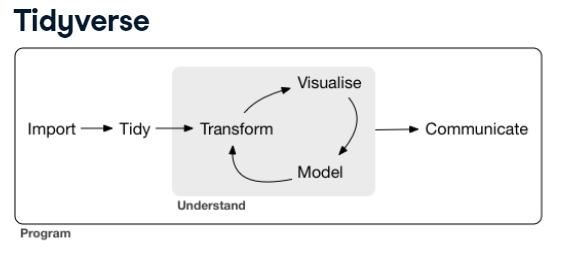

Figura tomada de DataCamp

**¿CÓMO MANIPULAR LOS DATA FRAMES?**

El paquete **dplyr** del tidyverse posee funciones que realizan algunas de las operaciones más comunes cuando se trabaja con los *data frames*, permitiendo manipular de una forma ágil la base de datos que queremos analizar *a posteriori*.

Veamos algunas **funciones claves**:

- Para cambiar la tabla de datos agregando una nueva columna, utilizamos **mutate()**.
- Para filtrar la tabla de datos a un subconjunto de filas, utilizamos **filter()**.
- Para subdividir los datos seleccionando columnas específicas, usamos **select()**.

**PRODUCCIÓN Y DISPONIBILIDAD NACIONAL DE OVAS 2016-2017**

El año 2017, la producción nacional de ovas aumentó en un 9% en relación al año 2016. El principal proveedor de ovas de salmónidos es Islandia.

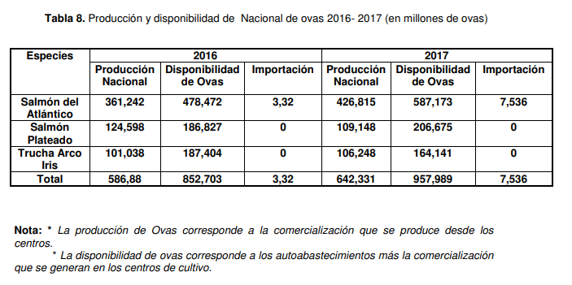

Figura tomada de informe de Sernapesca

**FILTRAR DATOS DE PRODUCCIÓN Y DISPONIBILIDAD NACIONAL DE OVAS DEL AÑO 2016**

```r
filter(Year == 2016)
```

Producción y disponibilidad de Nacional de ovas 2016-2017 (en millones de ovas).

[output not shown]

**AGRUPAR DATOS DE PRODUCCIÓN Y DISPONIBILIDAD NACIONAL DE OVAS PARA LOS AÑOS EVALUADOS**

```r
group_by(Year)
```

Producción y disponibilidad de Nacional de ovas 2016-2017 (en millones de ovas).

| Especies | Year | ProdNac | DispOvas | Importacion |
| --- | --- | --- | --- | --- |
| Salmón del Atlántico | 2016 | 361.24 | 478.47 | 3.32 |
| Salmón Plateado | 2016 | 124.60 | 186.83 | 0.00 |
| Trucha Arcoiris | 2016 | 101.04 | 187.40 | 0.00 |
| Salmón del Atlántico | 2017 | 426.82 | 587.17 | 7.54 |
| Salmón Plateado | 2017 | 109.15 | 206.68 | 0.00 |
| Trucha Arcoiris | 2017 | 106.25 | 164.14 | 0.00 |

**SELECCIONAR VARIABLES DE LOS DATOS DE PRODUCCIÓN Y DISPONIBILIDAD NACIONAL DE OVAS**

```r
select(Especies, Year,ProdNac)
```

Producción y disponibilidad de Nacional de ovas 2016-2017 (en millones de ovas).

[output not shown]

**MEDIDAS RESUMEN POR VARIABLE**

```r
summarize(Min_ProdNac = min(ProdNac), Max_ProdNac = max(ProdNac))
```

```
## # A tibble: 1 x 2
##   Min_ProdNac Max_ProdNac
##         <dbl>       <dbl>
## 1        101.        427.
```

Producción y disponibilidad de Nacional de ovas 2016-2017 (en millones de ovas).

| Especies | Year | ProdNac | DispOvas | Importacion |
| --- | --- | --- | --- | --- |
| Salmón del Atlántico | 2016 | 361.24 | 478.47 | 3.32 |
| Salmón Plateado | 2016 | 124.60 | 186.83 | 0.00 |
| Trucha Arcoiris | 2016 | 101.04 | 187.40 | 0.00 |
| Salmón del Atlántico | 2017 | 426.82 | 587.17 | 7.54 |
| Salmón Plateado | 2017 | 109.15 | 206.68 | 0.00 |
| Trucha Arcoiris | 2017 | 106.25 | 164.14 | 0.00 |

**REPRESENTACIÓN GRAFICA USANDO GGPLOT2**

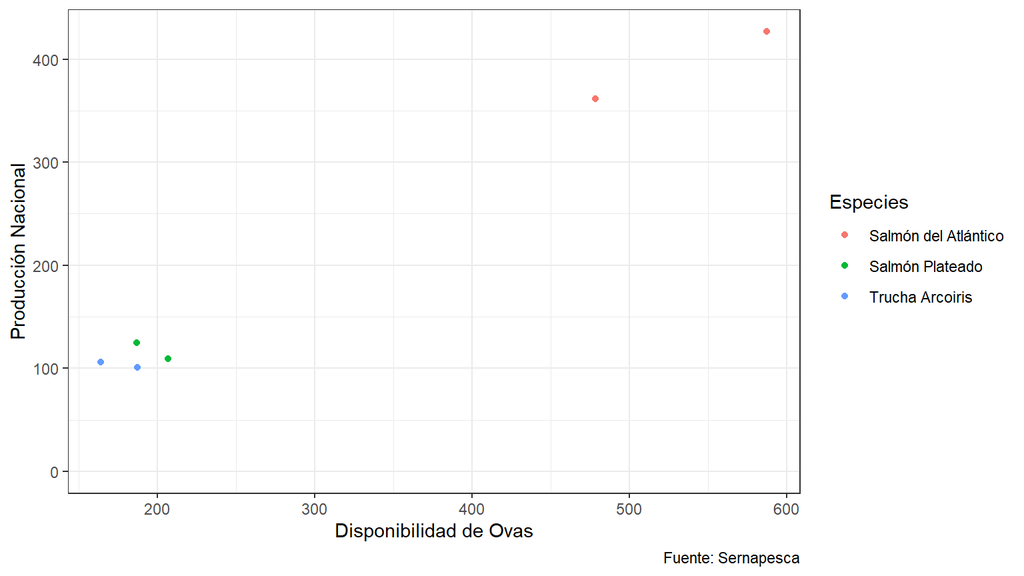

**Práctica**

*Clase 7 – Manipulación de bases de datos*

**TRABAJO EN SALAS**

**1).** **Guía de trabajo programación con R disponible en drive.**

**2).** **La tarea se realiza en Rstudio.cloud**.

Ingresa al siguiente proyecto de **[Rstudio.Cloud](https://rstudio.cloud/spaces/135178/project/2447826/)**

**RESUMEN DE LA CLASE**

- Revisar ventajas de manipular bases de datos con *Tidyverse*.
- Escribir un código de programación con **Rmardown**
- Elaborar diferentes reportes dinámicos.